# CodBodyCondition

MS

2025-05-20

In this project, I use DFO data on cod from 1977-2021 to create a model describing body condition overtime. In this script we will open the cleaned data file then go through model selection. After creating the optimal model, we use plotting functions to be able to visually interpret the model results.

## Data Set Up

Here we load in relevant packages and our cleaned data.

```r
knitr::opts_chunk$set(warning = FALSE, message = FALSE)
library(viridis)
library(sf)
library(tidyverse)
library(glmmTMB)
library(dplyr)
library(ggOceanMaps)
library(patchwork)
library(ggeffects)
library(extrafont)
library(corrplot)
library(data.table)

load('gutcod_clean.RData') #df cleaned and including relevant colums
                          #outliers and NAs removed, individuals under 15cm removed
                          #after initial model creation we also removed the outliers
                          #that were out of the general trend of residuals

#data is set up with columns denoting: year, month, day, species, length, sex, weight, age,
#NAFO Division, season, maturity, gutted weight, gonad weight, length bin, and a dummy varible
```

Next we go through model selection using GLMMTMB starting from the most simple model. As we make more complex models we compare the number of effects and the AIC/BIC. These models use a quadratic variace structure to account for increasing varation in weight for larger cod.

```r
    #model testing from motel table in Results
#                                       fixed eff
#M1 <- glmmTMB(log(gutwt) ~ log(length) + NAFOdiv,
#               dispformula =~ poly (log(length),2), data=gutcod_clean)
#AIC        BIC
#-202212.5 -202116.4
#nodisp
#AIC        BIC
#-199213.91 -199136.98

#M2 <- glmmTMB(log(gutwt) ~ log(length) + NAFOdiv + ar1(month|dum),
#                dispformula =~ poly (log(length),2), data=gutcod_clean)
#AIC        BIC
#-212998.9 -212883.5
#nodisp
#AIC        BIC
#-208447.9 -208351.7

#M3 <- glmmTMB(log(gutwt) ~ log(length) + NAFOdiv + ar1(month|dum) +
#                lenbin,
#                dispformula =~ poly (log(length),2), data=gutcod_clean)
#AIC        BIC
#-214715.3 -214580.7
#nodisp
#AIC        BIC
#-210048.7 -209933.3

#M4 <- glmmTMB(log(gutwt) ~ log(length) + NAFOdiv + ar1(month|dum) + ar1(month-1|lenbin) +
#                lenbin,
#                dispformula =~ poly (log(length),2), data=gutcod_clean)
#AIC        BIC
#-215671.2 -215517.3
#nodisp
#AIC        BIC
#-211302.6 -211168.0

#M5 <- glmmTMB(log(gutwt) ~ log(length) + NAFOdiv + ar1(month-1|dum) +
#                ar1(month-1|lenbin),
#                dispformula =~ poly (log(length),2), data=gutcod_clean)
#AIC        BIC
#-215666.8 -215532.2
#nodisp
#AIC        BIC
#-211300.2 -211184.8

#M6 <- glmmTMB(log(gutwt) ~ log(length) + NAFOdiv + ar1(month-1|dum) +
#                ar1(month-1|lenbin) + ar1(month-1|year),
#                dispformula =~ poly (log(length),2), data=gutcod_clean)
#AIC        BIC
#-221781.4 -221627.5
#nodisp
#AIC        BIC
#-216677.9 -216543.3

#M7 <- glmmTMB(log(gutwt) ~ log(length) + NAFOdiv + ar1(month-1|dum) +
#                ar1(month-1|lenbin) + ar1(month-1|year) + ar1(year-1|dum),
#                dispformula =~ poly (log(length),2), data=gutcod_clean)
#AIC        BIC
#na          na
#nodisp
#AIC        BIC
#-216686.7 -216532.8

#M8 <- glmmTMB(log(gutwt) ~ log(length) + NAFOdiv + ar1(month|dum) +
#                ar1(month-1|lenbin) + ar1(year-1|dum),
#                dispformula =~ poly (log(length),2), data=gutcod_clean)
#AIC        BIC
#na          na
#nodisp
#AIC        BIC
#-214101.5 -213966.9

#M9 <- glmmTMB(log(gutwt) ~ log(length) + NAFOdiv + ar1(month|dum) +
#                ar1(month-1|lenbin) + ar1(year-1|dum) + ar1(year-1|month),
#                dispformula =~ poly (log(length),2), data=gutcod_clean)
#AIC        BIC
#-221792.4 -221619.3
#nodisp
#AIC        BIC
#-216694.1 -216540.2

#M10 <- glmmTMB(log(gutwt) ~ log(length) + NAFOdiv + ar1(month|dum) +
#                ar1(month-1|lenbin) + ar1(year-1|month),
#                dispformula =~ poly (log(length),2), data=gutcod_clean)
#AIC        BIC
#-221780.0 -221626.2
#nodisp
#AIC        BIC
#-216659.8 -216525.2

#M11 <- glmmTMB(log(gutwt) ~ log(length) + NAFOdiv + ar1(month|dum) +
#                ar1(month-1|lenbin) + ar1(year-1|month) + ar1(month-1|year),
#                dispformula =~ poly (log(length),2), data=gutcod_clean)
#AIC        BIC
#na          na
#nodisp
#AIC        BIC
#-216694.0 -216540.1

#M12 <- glmmTMB(log(gutwt) ~ log(length) + NAFOdiv + ar1(month|dum) +
#                ar1(month-1|lenbin) + ar1(year-1|month) + sex,
#                dispformula =~ poly (log(length),2), data=gutcod_clean)
#AIC        BIC
#-221778.2 -221614.7
#nodisp
#AIC        BIC
#-216670.2 -216526.0

#M13 <- glmmTMB(log(gutwt) ~ log(length) + NAFOdiv + ar1(month|dum) +
#                ar1(month-1|lenbin) + ar1(year-1|month) + sex + ar1(year-1|NAFOdiv),
#                dispformula =~ poly (log(length),2), data=gutcod_clean)
#AIC        BIC
#-223228.6 -223045.8
#nodisp
#AIC        BIC
#-217887.6 -217724.1

#M14 <- glmmTMB(log(gutwt) ~ log(length) + NAFOdiv + ar1(month|dum) +
#                ar1(month-1|lenbin) + ar1(year-1|month) + ar1(year-1|NAFOdiv),
#                dispformula =~ poly (log(length),2), data=gutcod_clean)
#AIC        BIC
#-223230.2 -223057.1

#nodisp
#AIC        BIC
#-217877.3 -217723.4

#save(M14, file = 'M14.RData')
load('M14.RData')


#TM14 <- glmmTMB(log(weight) ~ log(length) + NAFOdiv + ar1(month-1|dum) +
#                ar1(month-1|lenbin) + ar1(year-1|month) + ar1(year-1|NAFOdiv),
#                dispformula =~ poly (log(length),2), data=gutcod_clean)

#only works with this disp formula
#AIC        BIC
#-194417.83 -194244.73

#save(TM14, file = 'TM14.RData')
load('TM14.RData')

#number of fixed and random effects in model table p & q

num_effs <- function(model){
  num_fixed <- length(model$fit$par)
  print('Fixed Effects:')
  print(num_fixed)

  num_random <- length(unlist(ranef(model)))
  print('Random Effects:')
  print(num_random)
}
```

## Plotting The Predicted Gutted Weight

The following 2 plots represent the predicted gutted weight of a 40cm individual Atlantic Cod in a single month from 1977 - 2021. Different color lines represent different NAFO Divisions.

May:

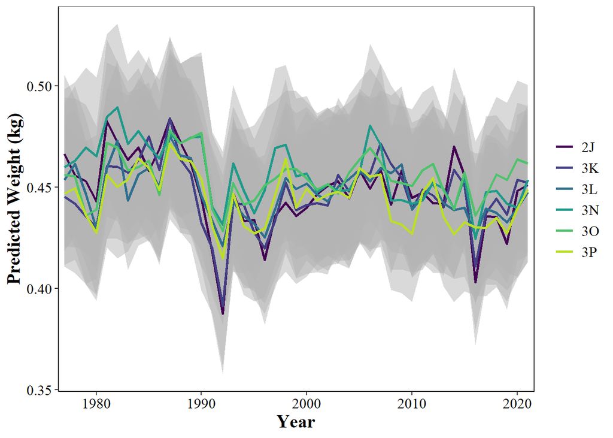

June:

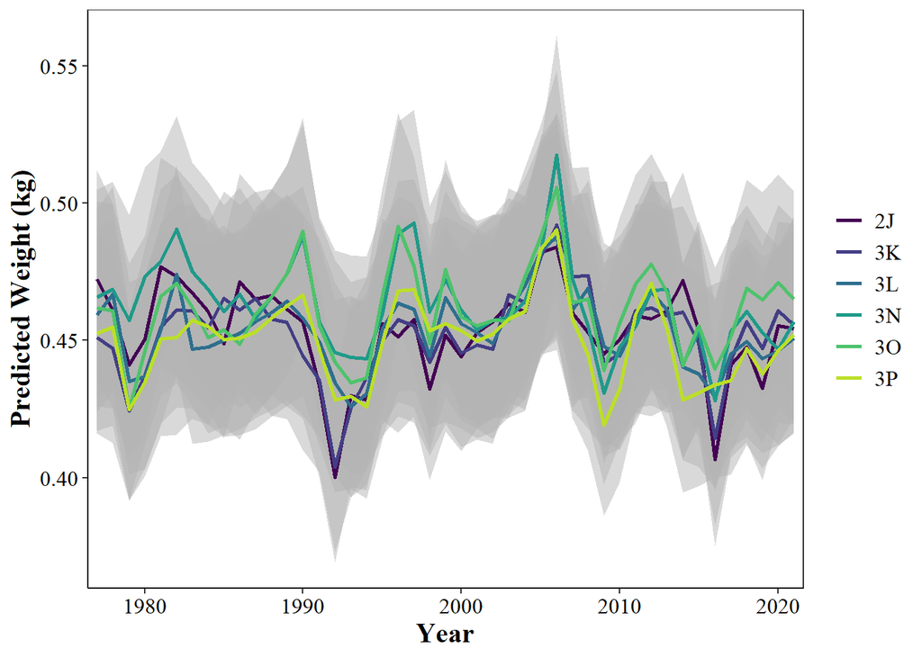

## Plotting The Gutted Model Effects

These plots show the individual effects of each of the variables included in the model. These effects aggregate so looking at individual plots will not show the full picture unlike the previous predicted weight plots.

First we plot the effect of month on condition.

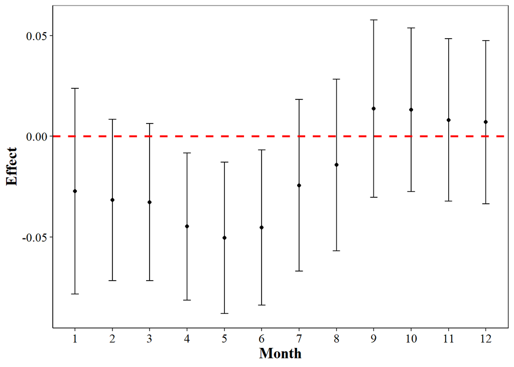

Next we plot the fixed effect of NAFO Division. This effect includes the intercept effect so the results are negative. This can be ignored as the intercept effect does not change the relative difference between divisions.

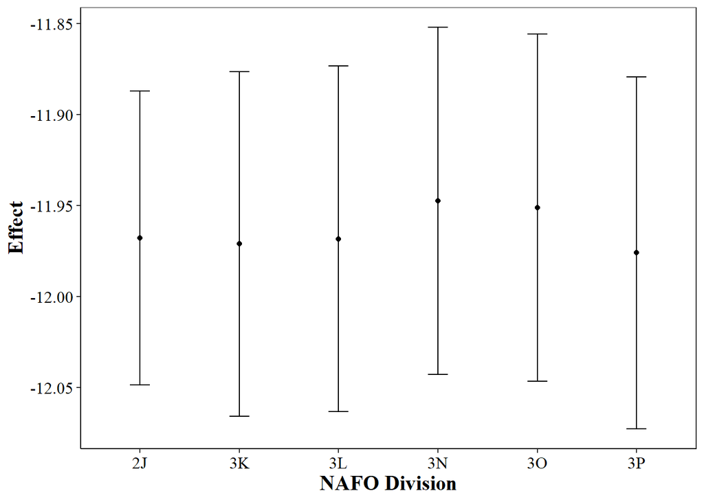

The Year by NAFO division effect is our first random interaction effect. This plot shows how condition has changed over time in each division.

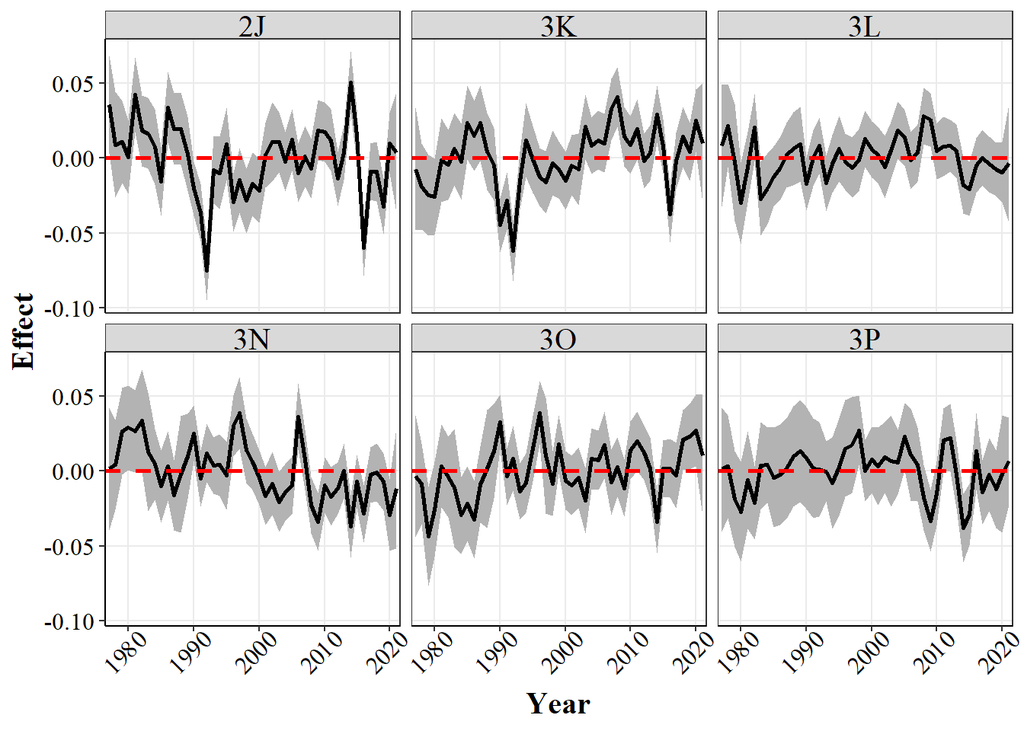

The month by length bin effect shows the seasonality of condtion for different length groups.

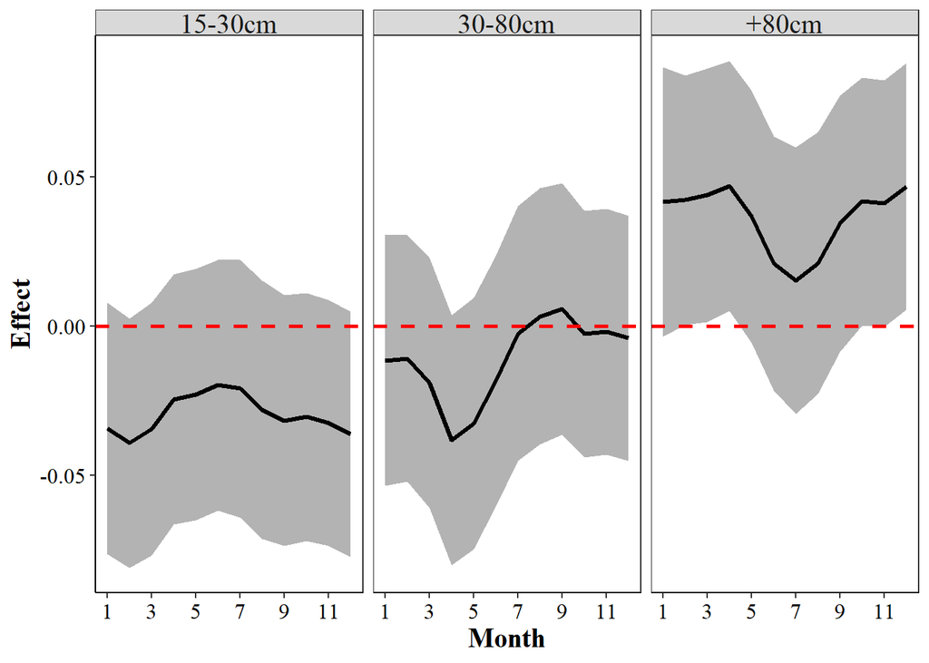

The year by month effect shows how seasonality affects condition over time. This effect highlights how factors like prey availibility changes over time.

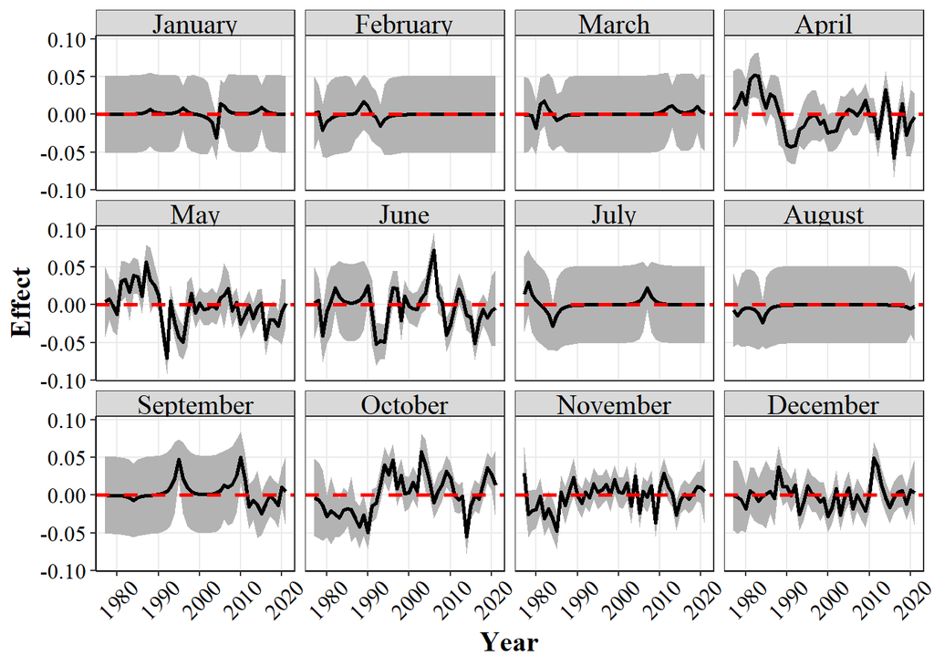

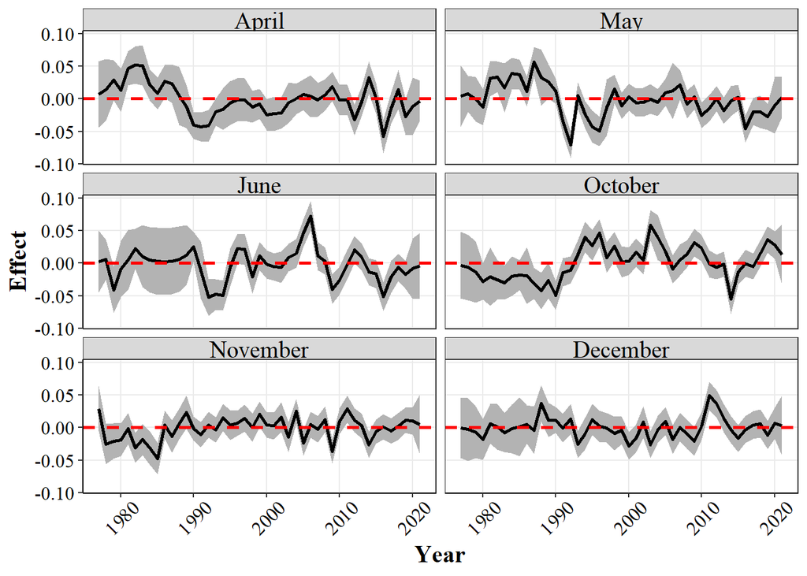

## Total vs Gutted Model Effects

These plots show the difference in individual model effects of the total (blue) and gutted (black) weight model. Fixed effects like NAFO division or month were not included because of the high degree of overlap. First we have the Year by Nafo Effect.

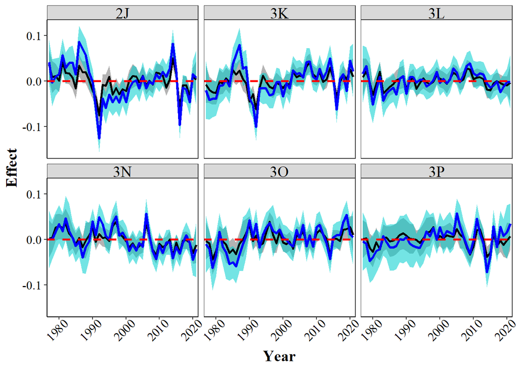

Next is the year grouped by month effect.

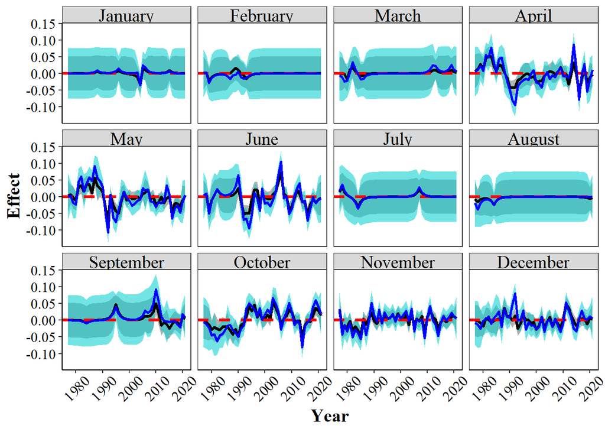

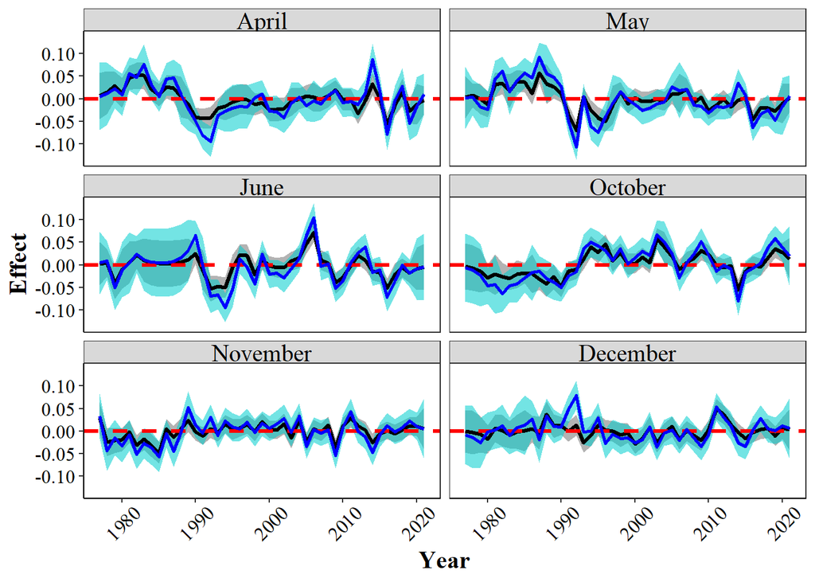

Next we have the month grouped by length bin effect.

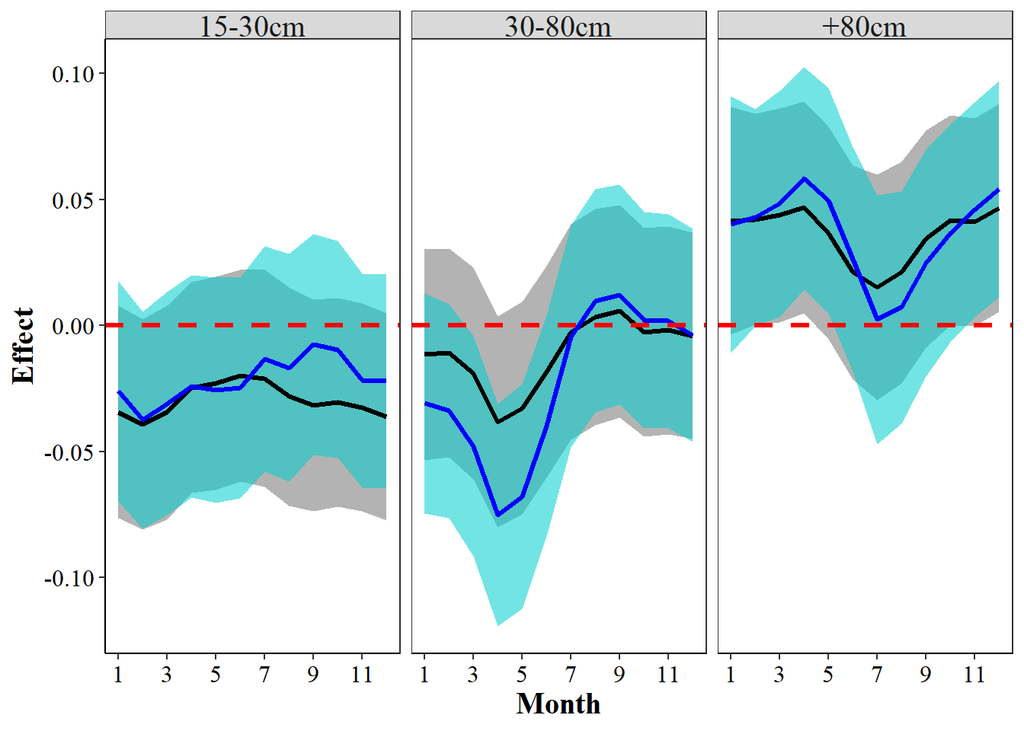

## Model Residuals

These plots show the residual plots of the model. Default shows the gutted weight model but there is code to show the total weight model as well.

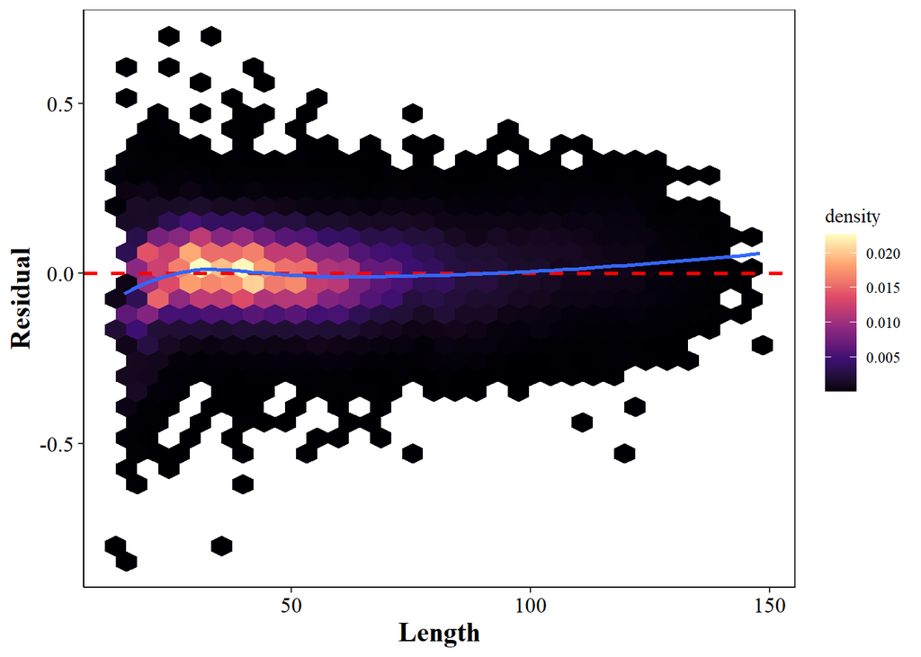

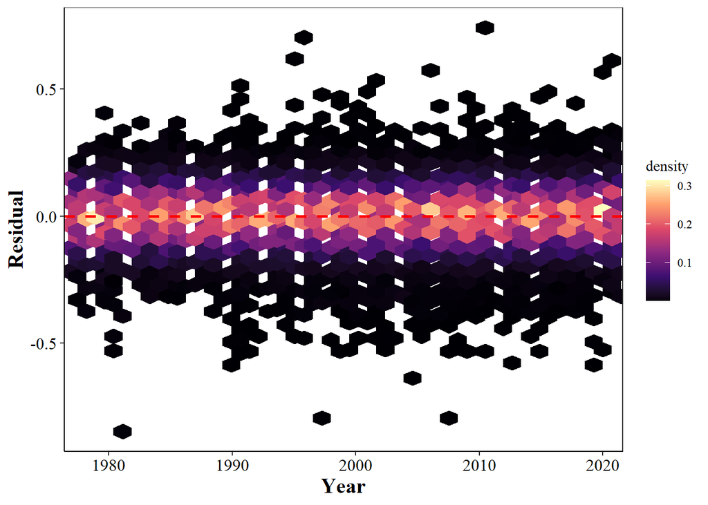

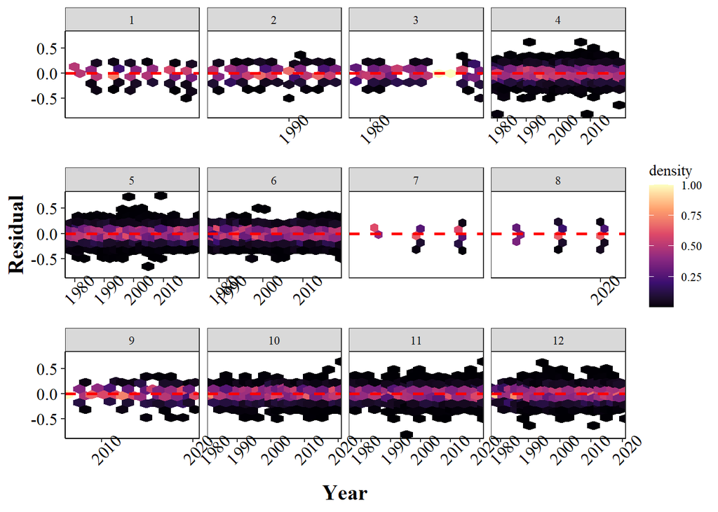

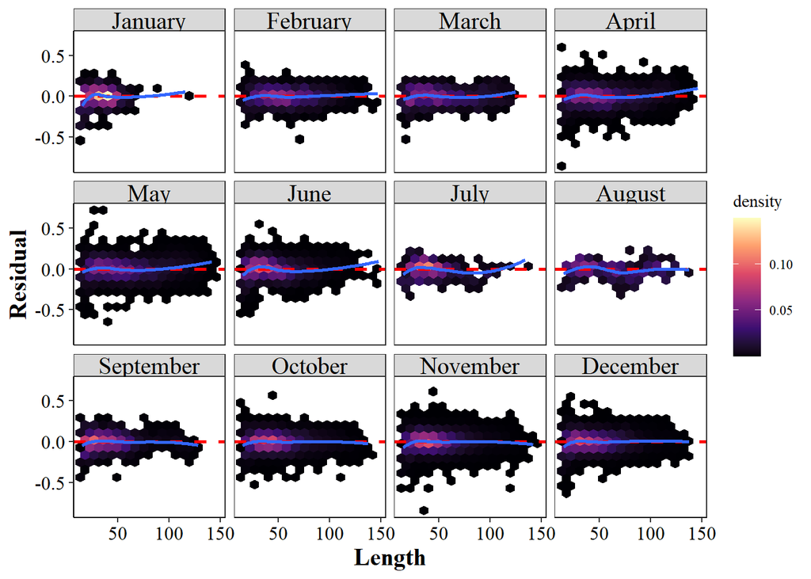

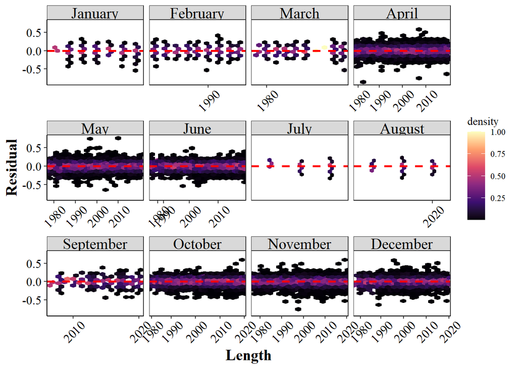

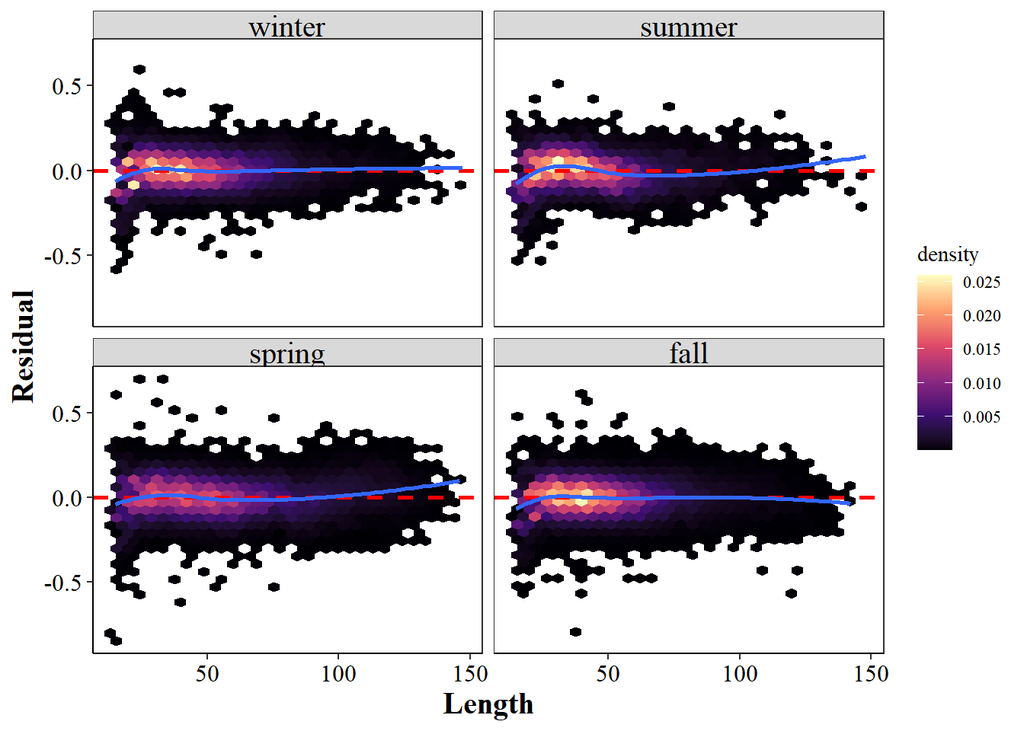

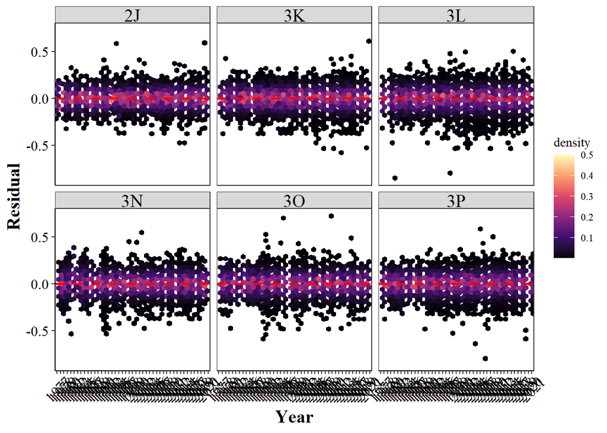

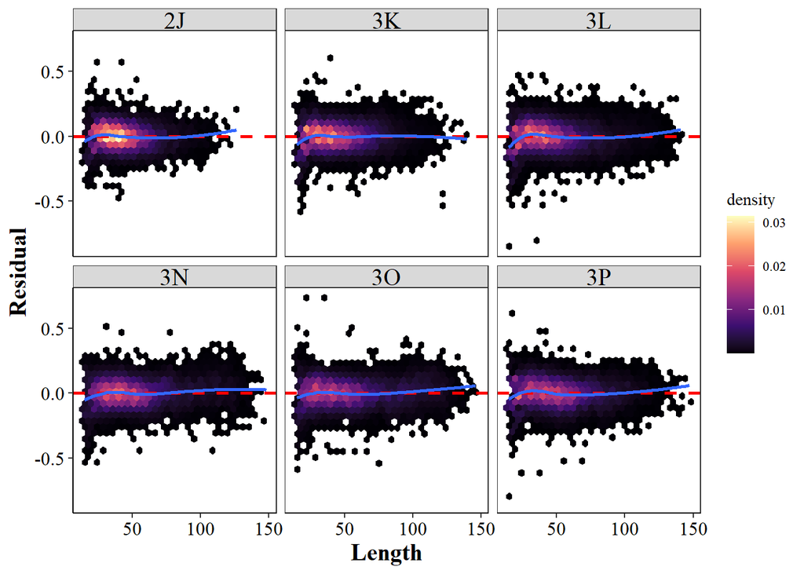

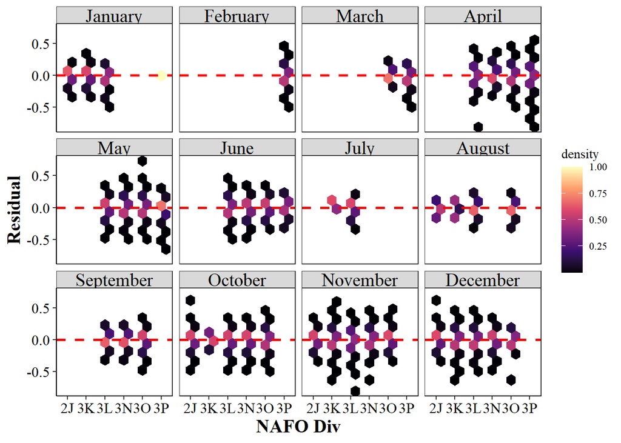

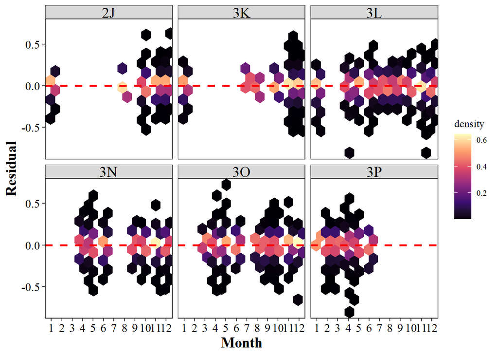

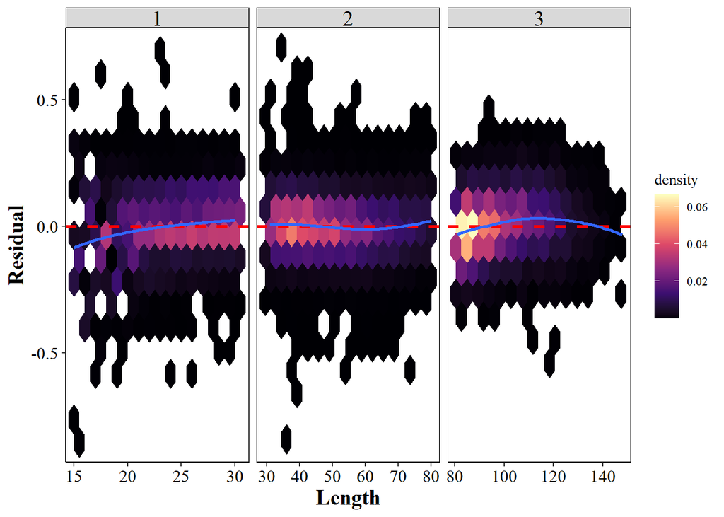

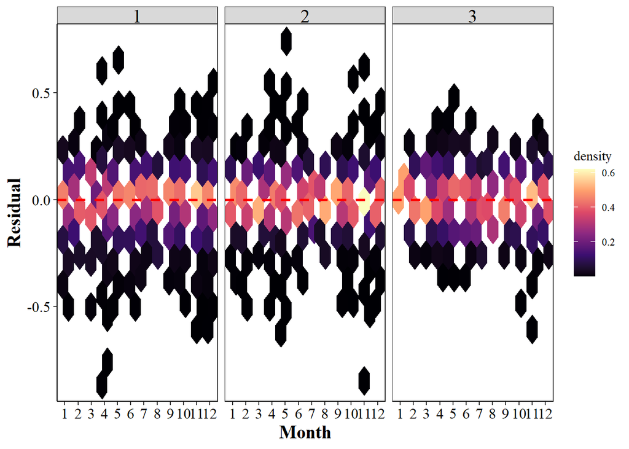

[10 more figures not shown]

## Predicted vs Actual

Below we check the predicted vs actual values that our model estimated compared to observed data.

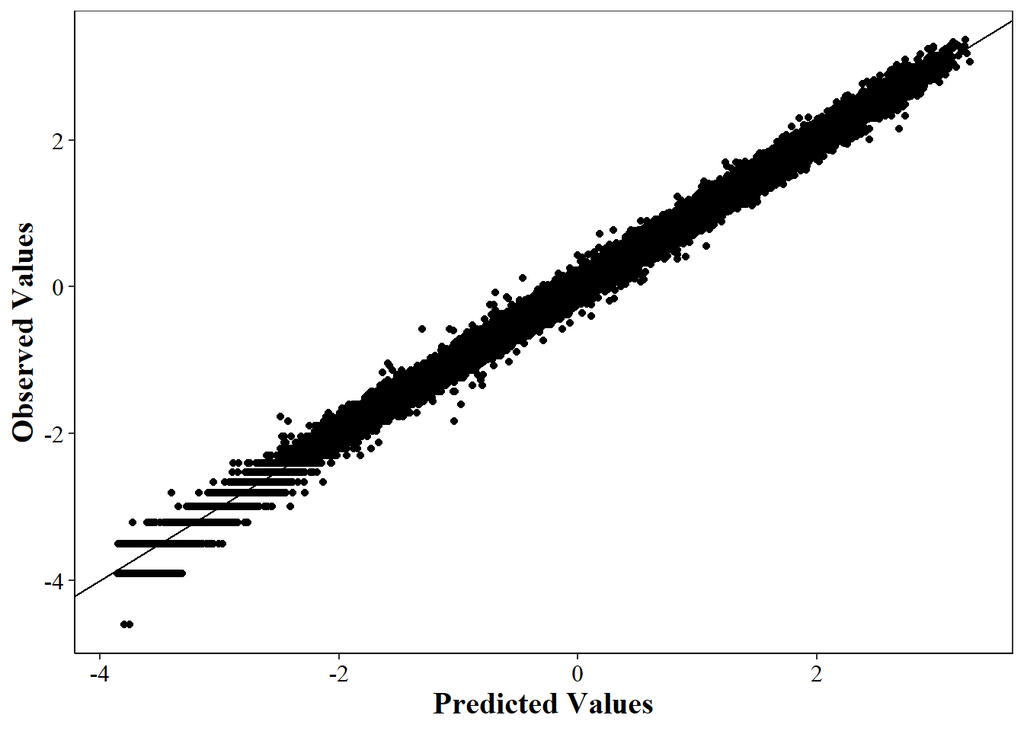

```r
predicted_actual <- function(model){
  p <- ggplot(data = gutcod_clean, aes(x=predict(model), y=log(gutwt)))+
    geom_point()+
    xlab('Predicted Values')+
    ylab('Observed Values')+
    geom_abline(slope = 1, intercept = 0, )+
    theme_bw()+
        theme(axis.text.x = element_text(size=12, colour = "black"),
              axis.text.y = element_text(size=12, colour = "black"),
              axis.title.x = element_text(size=15, face="bold", colour = "black"),
              axis.title.y = element_text(size=15, face="bold", colour = "black"),
              strip.text = element_text(size=15, colour = "black"),
              panel.grid.major = element_blank(), panel.grid.minor = element_blank(),
              panel.background = element_blank(), axis.line = element_line(colour = "black"),
              text=element_text(family="Times New Roman"),
              strip.text.x = element_text(margin = margin(0.0,0,0.0,0, "cm")))
  p
  # ggsave(filename = 'predicted_actual.jpeg', device = "jpeg", plot = p, dpi=400, units="in", width=8, height=5)
}

predicted_actual(M14)
```

```r
#predicted_actual(TM14)
```

Similar to the last plot we also show this plot as a histogram.

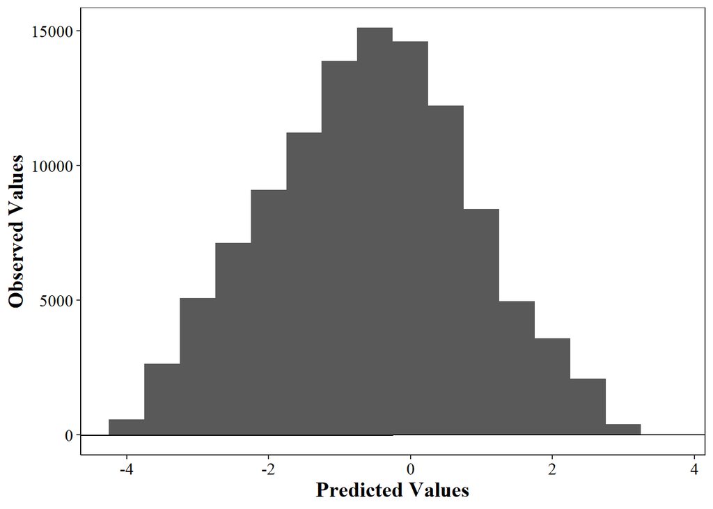

```r
predicted_actual_histogram <- function(model){
  p <- ggplot(data = gutcod_clean, aes(x=predict(model)))+
    geom_histogram(binwidth = .5)+
    xlab('Predicted Values')+
    ylab('Observed Values')+
    geom_abline(slope = 1, intercept = 0, )+
    theme_bw()+
        theme(axis.text.x = element_text(size=12, colour = "black"),
              axis.text.y = element_text(size=12, colour = "black"),
              axis.title.x = element_text(size=15, face="bold", colour = "black"),
              axis.title.y = element_text(size=15, face="bold", colour = "black"),
              strip.text = element_text(size=15, colour = "black"),
              panel.grid.major = element_blank(), panel.grid.minor = element_blank(),
              panel.background = element_blank(), axis.line = element_line(colour = "black"),
              text=element_text(family="Times New Roman"),
              strip.text.x = element_text(margin = margin(0.0,0,0.0,0, "cm")))
  p
  #ggsave(filename = 'predicted_actual_histogram.jpeg', device = "jpeg", plot = p, dpi=400, units="in", width=8, height=5)
}

predicted_actual_histogram(M14)
```

```r
#predicted_actual_histogram(TM14)
```

## Correlation Plots

Next we show the correlation matrix between the different NAFO divisions over time

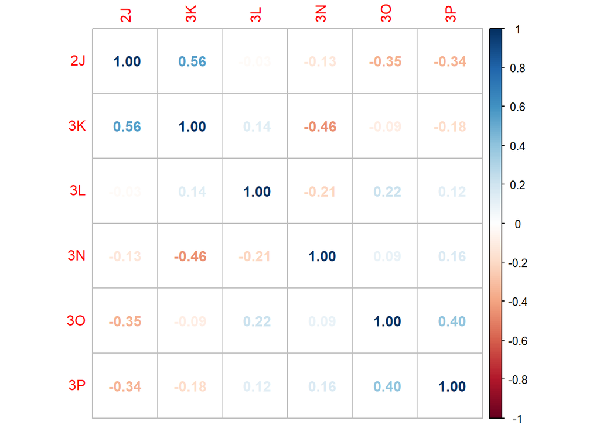

```r
NAFO_year_corr_plot <- function(model=M14,df=gutcod_clean){  #function pulls a model, using mod11 and cod df

numyears <- nlevels(df$year) #understands the amount of years in dataset
nafos <- levels(df$NAFOdiv) #creates vector of NAFO divs in order
nafonum <- length(nafos)  #takes number of NAFO divs

effects <- ranef(model)
efnafo <- as.data.frame(x=effects$cond$NAFOdiv) #create large df with main effect of year

NAFOdiv <- rep(nafos,12)

ef_year <- efnafo[,1:numyears] #this works by assessing the levels of years in the df
year <- rep(seq(1977,2021),each = nafonum)
NAFOdiv <- rep(nafos,numyears)
ef_year_final <- as.data.frame(year,NAFOdiv)

yints <- character()
all_yints <- c()   #df for all point estimates

for (i in 1:ncol(ef_year)) {
  yints <- ef_year[i]
  all_yints <- c(all_yints, yints[,1])  #use for loop to pull out the relevant intercepts
}

ef_year_final$effect <- all_yints
ef_year_final <- tibble::rownames_to_column(ef_year_final, var= 'NAFOdiv')  #flip df
ef_year_final[1:2] <- lapply(ef_year_final[1:2], as.factor)

yearlist <- as.character(seq(1977,2021))
for (i in 1:length(yearlist)) {
  yearlist[i] <- paste('year', yearlist[i], sep='')
}

conf <- as.data.frame(glmmTMB::ranef(model, condVar = TRUE))
year_conf <- subset(conf,term %in% yearlist & conf$grpvar == 'NAFOdiv')


ef_year_final$sd <- year_conf$condsd

ef_year_final <- ef_year_final %>%  #manually create the 95% CIs
  mutate(lower = effect - (1.96*sd)) %>%
  mutate(upper = effect + (1.96*sd))


df_wide <- ef_year_final %>%
  select(NAFOdiv, year, effect) %>%      # Keep only the relevant columns
  pivot_wider(names_from = NAFOdiv,      # Use NAFO divisions as column names
              values_from = effect) %>%
  arrange(year)

df_wide$year <- as.character(df_wide$year)
df_wide$year <- as.numeric(df_wide$year)

cor_matrix <- cor(df_wide[,2:7])

#jpeg(file="M14_NAFO_corr.jpeg", res=400, units="in", width=8, height=5)
corrplot(cor_matrix, method = 'number')
#dev.off()

}
NAFO_year_corr_plot()
```

This correlation matrix shows the similarity between different months over years.

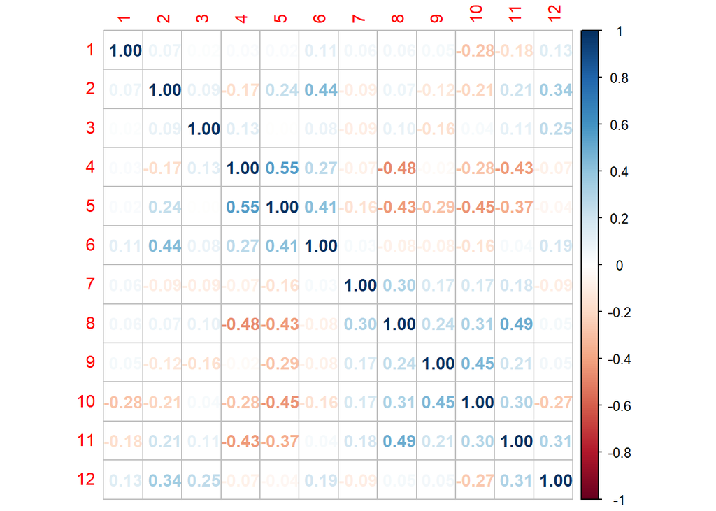

```r
####################################
##################################

month_year_corr_plot <- function(model=M14,df=gutcod_clean, subset=FALSE){  #function pulls a model, using mod11 and cod df

  effects <- ranef(model)
  ef_year <- as.data.frame(x=effects$cond$month) #create large df with main effect of month on its own
  month <- rep(seq(1,12), 45)
  year <- rep(seq(1977,2021),each=12)

  ef_year_final <- as.data.frame(year,month)
  ef_year_final <- tibble::rownames_to_column(ef_year_final, var= 'month')

  ints <- character()
  all_ints <- c()

  for (i in 1:ncol(ef_year)) {
    ints <- ef_year[i]
    all_ints <- c(all_ints, ints[,1])
  }
  ef_year_final$effect <- all_ints

  yearlist <- as.character(seq(1977,2021))
  monthlist <- c('month1','month2','month3','month4','month5','month6',
                 'month7','month8','month9','month10','month11','month12')

  for (i in 1:length(yearlist)) {
    yearlist[i] <- paste('year', yearlist[i], sep='')
  }

  conf <- as.data.frame(glmmTMB::ranef(model, condVar = TRUE))
  year_conf <- subset(conf, conf$grpvar == 'month') #term %in% monthlist &


  ef_year_final$sd <- year_conf$condsd

  ef_year_final <- ef_year_final %>%
    mutate(lower = effect - 1.96*sd) %>%
    mutate(upper = effect + 1.96*sd)

  ef_year_final$month <- as.numeric(ef_year_final$month)
  ef_year_final$month <- as.factor(ef_year_final$month)
  ef_year_final$month <- ordered(ef_year_final$month)

  # subset plot
  sub <- ''
  if (subset == TRUE) {
    sub <- '_subset'
    mainmonths <- c(4,5,6,10,11,12)
    ef_year_final <- ef_year_final %>%
      filter(month %in% mainmonths)
  }


  monthnames <- c('1'='January', '2'='February', '3'='March', '4'='April', '5'='May',
                  '6'='June', '7'='July', '8'='August', '9'='September', '10'='October',
                  '11'='November', '12'='December')


  ef_year_final$month <- as.numeric(ef_year_final$month)
  ef_year_final$year <- as.character(ef_year_final$year)
  ef_year_final$year <- as.numeric(ef_year_final$year)


  df_wide <- ef_year_final %>%
    select(month, year, effect) %>%      # Keep only the relevant columns
    pivot_wider(names_from = month,      # Use NAFO divisions as column names
                values_from = effect,
                names_sort = TRUE) %>%
    arrange(year)

  cor_matrix <- cor(df_wide[,2:13])

  #jpeg(file="M14_month_corr.jpeg", res=400, units="in", width=8, height=5)
  corrplot(cor_matrix, method = 'number')
  #dev.off()

}
month_year_corr_plot()
```

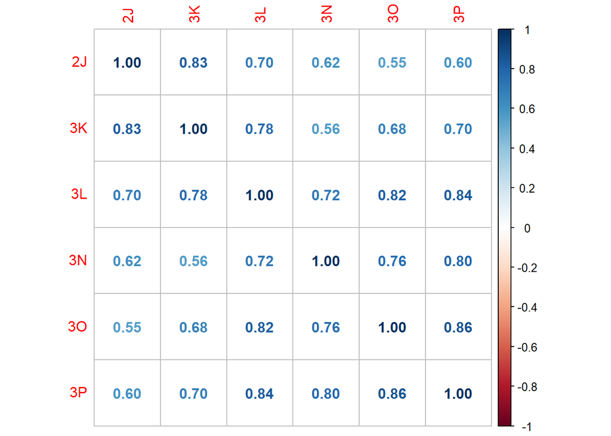

```r
pred_wt_corr_plot <- function(df,month){

  df_clean <- as.data.frame(df)

  df_clean$facet <- as.numeric(df_clean$facet)
  df_clean$x <- as.character(df_clean$x)
  df_clean$x <- as.numeric(df_clean$x)

  numeric_df <- df_clean[sapply(df_clean, is.numeric)]

  df_wide <- numeric_df %>%
    select(x, predicted, facet) %>%      # Keep only the relevant columns
    pivot_wider(names_from = facet,      # Use NAFO divisions as column names
                values_from = predicted) %>%
    arrange(x)

  df_wide <- df_wide[,2:7]

  names(df_wide) <- c("2J", "3K", "3L",
                 "3N", "3O", "3P")

  cor_matrix <- cor(df_wide)

  name <- paste("M14_pred_weight_",month,"_corr.jpeg")
  name <- str_replace_all(string=name, pattern=" ", repl="")

  #jpeg(file=name, res=400, units="in", width=8, height=5)
  corrplot(cor_matrix, method = 'number')
  #dev.off()
}
pred_wt_corr_plot(nafo_pred_june,'june')
```

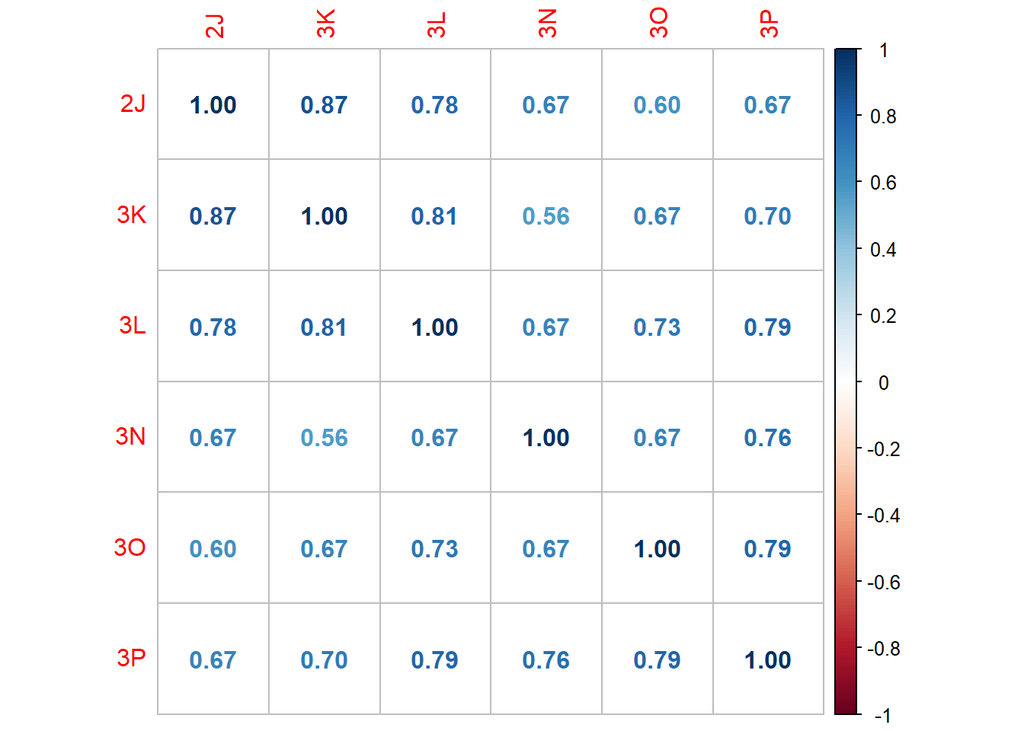

```r
pred_wt_corr_plot(nafo_pred_may,'may')
```

Lastly, we plot the predicted total and gutted weight for a 40cm atlantic cod across years.

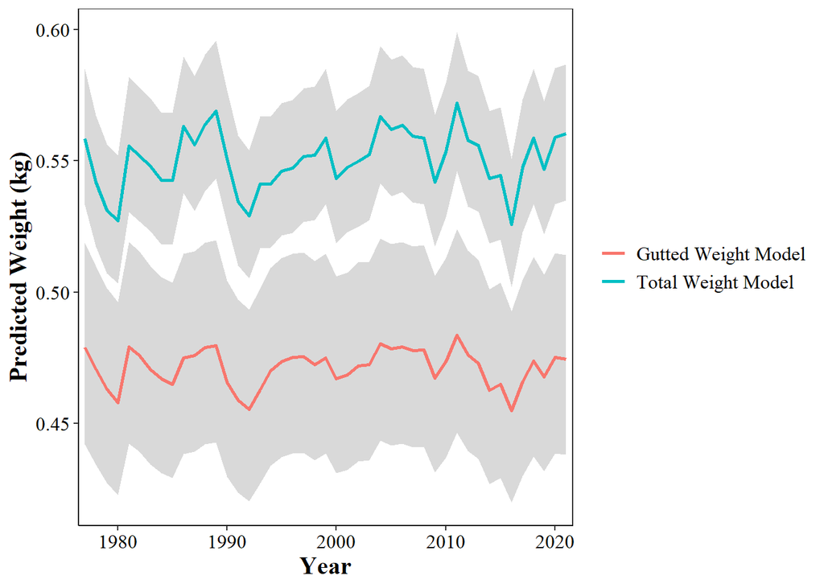

```r
#pred by year total vs gut

#pred_total <- predict_response(TM14, c('year','length[40]'), margin='empirical')
#save(pred_total, file='pred_total.RData')
load('pred_total.RData')

#pred_gut <- predict_response(M14, c('year','length[40]'), margin='empirical')
#save(pred_gut, file='pred_gut.RData')
load('pred_gut.RData')


total_gut_pred_weight <- function(total,gut){
  #combine dfs
  total$group <- 'Total Weight Model'
  gut$group <- 'Gutted Weight Model'
  pred_df <- bind_rows(total,gut)

  #plot ontop of one another
  p <- ggplot(pred_df, aes(x=x, y=predicted, group=group))  +
    geom_ribbon(aes(ymin = conf.low, ymax = conf.high), fill = "grey70", alpha=0.5) +
    geom_line(aes(color=group),linewidth=1)+
    xlab('Year')+
    ylab('Predicted Weight (kg)')+
    theme_bw()+
    scale_x_discrete(breaks = c(seq(1980,2020, 10))) +
    theme(legend.title = element_blank(),
          legend.text = element_text(size =12),
          axis.text.x = element_text(size=12, colour = "black"),
          axis.text.y = element_text(size=12, colour = "black"),
          axis.title.x = element_text(size=15, face="bold", colour = "black"),
          axis.title.y = element_text(size=15, face="bold", colour = "black"),
          strip.text = element_text(size =15),panel.grid.major = element_blank(), panel.grid.minor =
          element_blank(),
          panel.background = element_blank(), axis.line = element_line(colour = "black"),
          text=element_text(family="Times New Roman"),
          strip.text.x = element_text(margin = margin(0.0,0,0.0,0, "cm")))

  p
}

#jpeg(file="total_gut_pred_weight.jpeg", res=400, units="in", width=8, height=5)
total_gut_pred_weight(pred_total,pred_gut)
```

```r
#dev.off()
```